# What happens to resting BTC orders on HyperLiquid when price moves

## 4. Tools: render any odd-day moment, and see what was visible live

`show_event(day, "HH:MM:SS", seconds_before, seconds_after, price_pad_bps)` replays any window of an **odd** December day from the warehouse and draws it as an event card. It refuses an even day, a window that would open a neighbouring even day's hour file (keep windows between 01:00 and 22:59 UTC; Dec 1 00h is fine), and a window that touches a data outage.

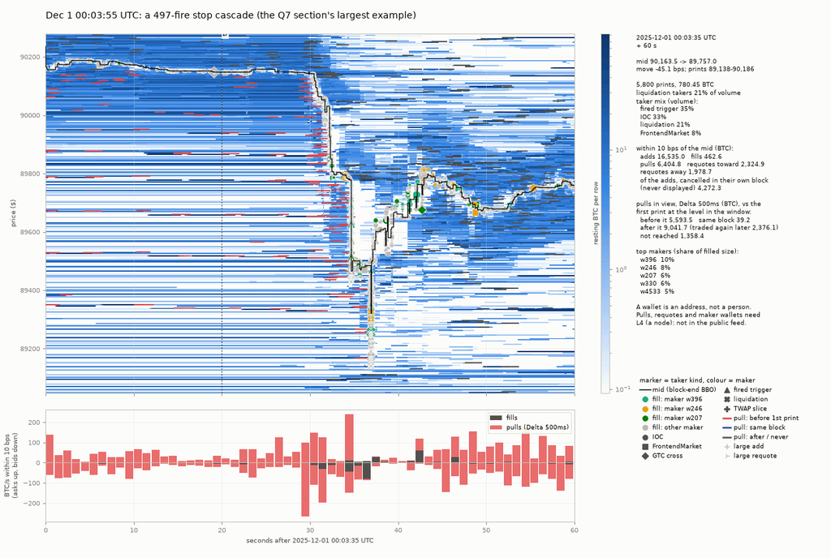

[figure not shown]

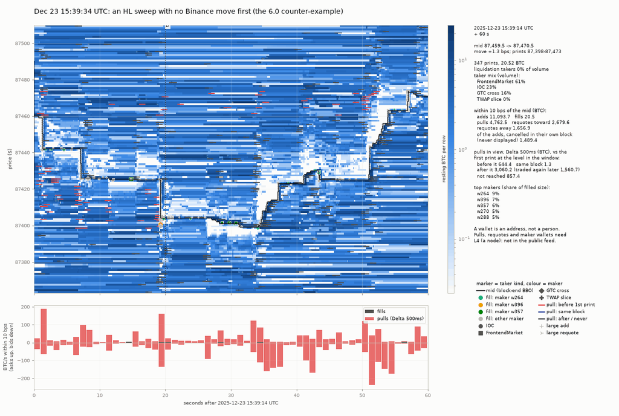

```python
def show_event(day, hhmmss: str, seconds_before: float = 30, seconds_after: float = 60,
               price_pad_bps: float = 5, *, title: str | None = None, mark: bool = True):
    """Render an event card for any ODD December 2025 day.

    day: 11, "11" or "20251211" (an even day raises PermissionError: the sealed lockbox).
    hhmmss: "HH:MM:SS" or "HH:MM:SS.fff", UTC. The card spans [t - seconds_before, t + seconds_after);
    its price axis is the window's traded + BBO range padded by price_pad_bps on each side.
    Returns the card's numbers (plots.draw_card stats)."""
    d = odd_day(day)
    t = T(f"{d[:4]}-{d[4:6]}-{d[6:]} {hhmmss}")
    t0, t1 = t - int(seconds_before * NS), t + int(seconds_after * NS)
    assert_odd_window(t0, t1)
    if touches_outage(t0, t1):
        raise ValueError(f"{utc(t0)} -> {utc(t1)} touches a data outage; pick another window")
    lo, hi = price_range(t0, t1, pad_bps=price_pad_bps)
    return render_card(t0, t1, lo, hi, title=title or f"Dec {int(d[-2:])} {hhmmss} UTC "
                       f"(-{seconds_before:g} s / +{seconds_after:g} s)", vlines=[(t, "t")] if mark else ())


# three ready-to-run examples (odd days only); `_ =` keeps the returned numbers from printing under the card
_ = show_event(1, "00:03:55", 20, 40, 10, title="Dec 1 00:03:55 UTC: a 497-fire stop cascade (the Q7 section's largest example)")
_ = show_event(15, "19:01:27", 20, 40, 5, title="Dec 15 19:01:27 UTC: a median-sized fast move (35 bps in 16 s)")
_ = show_event(23, "15:39:34", 20, 40, 4, title="Dec 23 15:39:34 UTC: an HL sweep with no Binance move first (the 6.0 counter-example)")
```

```python
try:
    show_event(8, "12:00:00")                   # an even day: refused, nothing is read
except PermissionError as err:
    print("refused:", err)
try:
    show_event(21, "13:45:00")                  # inside the Dec 21 outage: refused
except ValueError as err:
    print("refused:", err)
```

```
refused: Dec 8 is an EVEN day: the sealed lockbox. This notebook never reads it.
refused: 2025-12-21 13:44:30 -> 2025-12-21 13:46:00 touches a data outage; pick another window
```

`public_vs_l4(day, "HH:MM:SS", seconds_before, seconds_after, price_pad_bps, n_sig_figs=5)` draws the **same window twice**: on the left, what a trader could see live in December 2025 (the emulated `l2Book`: 20 levels a side on the `n_sig_figs` grid, one frame every ~0.54 s, gray where the feed shows nothing, plus the public prints by aggressor side); on the right, what the L4 data reveals (every resting order, the pulls by timing, and the taker type of each fill). `n_sig_figs=4` gives the $10 grid, which reaches further but merges levels.

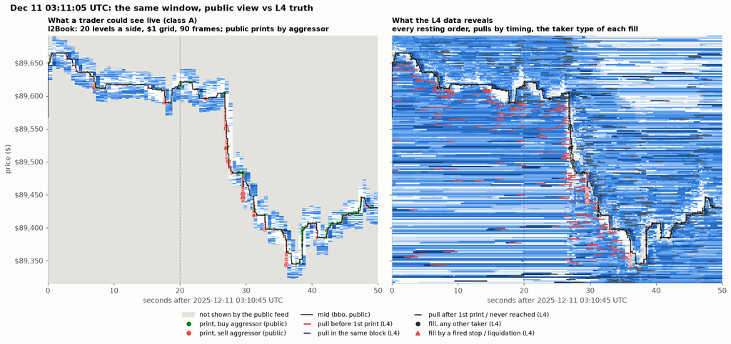

In this window the public feed covered a median **46 of the 377 $1 rows** on screen per frame. The L4 data adds: **11,356 BTC of pulls** in view (2,694 BTC before the first print at their price), and a taker mix of fired trigger 38%, IOC 32%, FrontendMarket 15%: none of that is in any public feed.

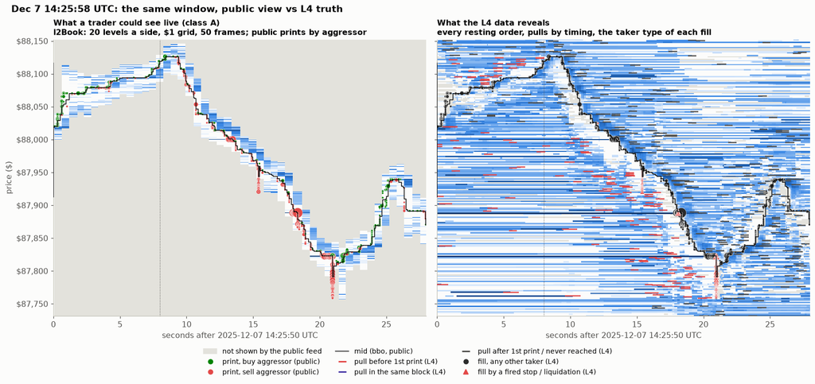

In this window the public feed covered a median **50 of the 423 $1 rows** on screen per frame. The L4 data adds: **8,392 BTC of pulls** in view (1,910 BTC before the first print at their price), and a taker mix of IOC 79%, liquidation 11%, fired trigger 9%: none of that is in any public feed.

```python
def public_vs_l4(day, hhmmss: str, seconds_before: float = 15, seconds_after: float = 30,
                 price_pad_bps: float = 4, n_sig_figs: int = 5):
    """The December-2025 public view (emulated l2Book + tape, class A) next to the L4 truth, same window."""
    d = odd_day(day)
    t = T(f"{d[:4]}-{d[4:6]}-{d[6:]} {hhmmss}")
    t0, t1 = t - int(seconds_before * NS), t + int(seconds_after * NS)
    assert_odd_window(t0, t1)
    if touches_outage(t0, t1):
        raise ValueError(f"{utc(t0)} -> {utc(t1)} touches a data outage; pick another window")
    if not RENDER_LIVE:
        display(Markdown(f"*(public vs L4 skipped in this run: {utc(t0)} → {utc(t1)})*"))
        return
    lo, hi = price_range(t0, t1, pad_bps=price_pad_bps)
    c = PL.load_card(DERIVED, t0, t1, int(np.floor(lo * 10)), int(np.ceil(hi * 10)), cols=360, max_rows=360)
    fr = EM.l2_snapshots(DERIVED, t0, t1, n_sig_figs=n_sig_figs)
    tape = EM.trades_tape(DERIVED, t0, t1)
    rlo, rhi = int(np.floor(lo)), int(np.ceil(hi))
    rows = np.arange(rlo, rhi + 1)                      # $1 rows, the same as the L4 panel's
    times = np.sort(fr.t.unique())
    M = np.full((rows.size, times.size), np.nan)
    for i, tf in enumerate(times):
        f = fr[fr.t == tf]
        for side in (0, 1):
            g = f[f.side == side]
            if not len(g):
                continue
            step = EM.grid_step(int(g.px.iloc[0]), n_sig_figs)      # the feed's grid, $0.1 units
            for px, sz in zip(g.px.to_numpy(np.int64), g.sz.to_numpy(np.int64)):
                a, b = ((px // 10, (px + step) // 10 - 1) if side == 0 else ((px - step) // 10 + 1, px // 10))
                ia, ib = max(a - rlo, 0), min(b - rlo, rows.size - 1)
                if ia <= ib:
                    M[ia:ib + 1, i] = sz / 1e5 / max(1, step // 10)   # BTC per $1 row
            # rows between the displayed extremes that the frame does not list are known-empty
            pxs = g.px.to_numpy(np.int64) // 10
            ia, ib = max(pxs.min() - rlo, 0), min(pxs.max() - rlo, rows.size - 1)
            if ia <= ib:
                seg = M[ia:ib + 1, i]
                seg[np.isnan(seg)] = 0.0
        bb = f[(f.side == 0) & (f.level == 0)].px
        aa = f[(f.side == 1) & (f.level == 0)].px
        if len(bb) and len(aa):                        # the spread is known-empty too
            ia, ib = max(int(bb.iloc[0]) // 10 + 1 - rlo, 0), min(int(aa.iloc[0]) // 10 - 1 - rlo, rows.size - 1)
            if ia <= ib:
                M[ia:ib + 1, i] = np.where(np.isnan(M[ia:ib + 1, i]), 0.0, M[ia:ib + 1, i])
    dep = np.where(c.depth > 0, c.depth, np.nan)
    fin = dep[np.isfinite(dep)]
    vmax = float(np.percentile(fin, 99.8)) if fin.size else 1.0
    vmin = max(float(np.percentile(fin, 2)) if fin.size else 1e-3, vmax / 1e3, 1e-4)
    norm = LogNorm(vmin=vmin, vmax=max(vmax, vmin * 10))
    cmap = PL.DEPTH_CMAP.copy()
    cmap.set_bad("#e3e2dc")
    fig, axs = plt.subplots(1, 2, figsize=(15, 6.3), sharey=True)
    xs = (times - t0) / NS
    ax = axs[0]
    ax.pcolormesh(np.r_[xs, xs[-1] + 0.54], np.r_[rows, rows[-1] + 1], np.ma.masked_invalid(np.where(M > 0, M, np.nan)),
                  cmap=cmap, norm=norm, shading="flat")
    known0 = np.where(np.isfinite(M) & (M == 0), 1.0, np.nan)
    ax.pcolormesh(np.r_[xs, xs[-1] + 0.54], np.r_[rows, rows[-1] + 1], np.ma.masked_invalid(known0),
                  cmap=ListedColormap([C["surface"]]), shading="flat")
    if len(tape):
        sell = tape.aggr_sell.to_numpy(bool)
        ax.scatter((tape.t - t0) / NS, tape.px / 10 + 0.5, s=6 + 30 * np.sqrt(tape.sz / 1e5),
                   c=np.where(sell, C["down"], C["up"]), marker="o", lw=0.3, edgecolors=C["surface"], zorder=5)
    ax.set_title(esc(f"What a trader could see live (class A)\nl2Book: 20 levels a side, {'$1' if n_sig_figs == 5 else 'coarse'} "
                     f"grid, {len(times)} frames; public prints by aggressor"), fontsize=10.5)
    ax = axs[1]
    ax.imshow(dep, origin="lower", aspect="auto", cmap=cmap, norm=norm, interpolation="nearest",
              extent=(0, (c.col_t[-1] - t0) / NS, c.row_px[0] / 10, (c.row_px[-1] + (c.row_px[1] - c.row_px[0])) / 10))
    p = c.pulls
    if len(p):
        p = p.nlargest(400, "pull")
        col = np.select([p.timing == PL.T_BEFORE, p.timing == PL.T_SAME], [C["pulled"], C["same"]], C["ink2"])
        ax.scatter((p.ts - t0) / NS, p.px / 10 + 0.5, s=6 + 60 * np.sqrt(p["pull"] / 1e5), marker="_", c=col, lw=1.6, zorder=5)
    tr = c.trades
    if len(tr):
        mech = tr.taker_kind.isin([3, 4]).to_numpy()
        for sel, mk, colr, lab in ((~mech, "o", C["filled"], "fill: other taker"),
                                   (mech, "^", C["pulled"], "fill: fired stop / liquidation")):
            g = tr[sel]
            ax.scatter((g.ts - t0) / NS, g.px / 10 + 0.5, s=6 + 30 * np.sqrt(g.sz / 1e5), marker=mk, c=colr,
                       lw=0.3, edgecolors=C["surface"], zorder=6)
    ax.set_title("What the L4 data reveals\nevery resting order, pulls by timing, the taker type of each fill", fontsize=10.5)
    for a in axs:
        m = c.mid
        mt = np.clip((m.ts.to_numpy() - t0) / NS, 0, None)
        a.step(mt, (m.bid_px + m.ask_px).to_numpy() / 20 + 0.5, where="post", color=C["ink"], lw=1.0, zorder=7)
        a.axvline((t - t0) / NS, color=C["ink2"], lw=0.8, ls=":")
        a.set_xlim(0, (t1 - t0) / NS)
        a.set_ylim(lo, hi)
        a.set_xlabel(f"seconds after {utc(t0)} UTC")
        a.grid(False)
    axs[0].set_ylabel("price ($)")
    axs[0].yaxis.set_major_formatter(lambda v, _: f"${v:,.0f}")
    handles = [Patch(color="#e3e2dc", label="not shown by the public feed"),
               Line2D([], [], ls="", marker="o", color=C["up"], label="print, buy aggressor (public)"),
               Line2D([], [], ls="", marker="o", color=C["down"], label="print, sell aggressor (public)"),
               Line2D([], [], color=C["ink"], lw=1, label="mid (bbo, public)"),
               Line2D([], [], ls="", marker="_", ms=11, mew=2, color=C["pulled"], label="pull before 1st print (L4)"),
               Line2D([], [], ls="", marker="_", ms=11, mew=2, color=C["same"], label="pull in the same block (L4)"),
               Line2D([], [], ls="", marker="_", ms=11, mew=2, color=C["ink2"],
                      label="pull after 1st print / never reached (L4)"),
               Line2D([], [], ls="", marker="o", color=C["filled"], label="fill, any other taker (L4)"),
               Line2D([], [], ls="", marker="^", color=C["pulled"], label="fill by a fired stop / liquidation (L4)")]
    fig.legend(handles=handles, loc="upper center", ncol=3, bbox_to_anchor=(0.5, 0.0), fontsize=9)
    fig.suptitle(esc(f"Dec {int(d[-2:])} {hhmmss} UTC: the same window, public view vs L4 truth"), x=0.01, ha="left",
                 fontsize=12.5, weight="bold")
    plt.show()
    N_LIVE["feeds"] += 1
    s = PL._stats(c)
    display(Markdown(esc(
        f"In this window the public feed covered a median **{np.nanmedian(np.isfinite(M).sum(0)):.0f} of the "
        f"{rows.size} $1 rows** on screen per frame. The L4 data adds: **{s['pulls_btc']:,.0f} BTC of pulls** in view "
        f"({s['pulls_by_timing_btc']['before touch']:,.0f} BTC before the first print at their price), and a taker mix "
        f"of " + ", ".join(f"{k} {100 * v:.0f}%" for k, v in list(s.get('taker_mix', {}).items())[:3])
        + ": none of that is in any public feed.")))


public_vs_l4(11, "03:11:05", 20, 30, 3)
public_vs_l4(7, "14:25:58", 8, 20, 3)
```

**What to look at.** On the left, gray is everything the December feed did not show: at the $1 grid the 20 levels a side reach only ~$20 from the touch, so most of a fast move's path is invisible until price is almost there. On the right, the same rows are full of resting size, and the **red dashes** show how much of it was cancelled before price arrived. A trader watching the public book saw net sizes shrink between snapshots; they could not see who pulled, or that the prints were fired stops.

## 5. Caveats, and what the confirmatory track tests next

**Caveats (read before using any number).**

- **Discovery half only.** 16 odd December days (Q1/Q3: 9 days; its fast moves: 8). No even-day file was read in any section, or in this notebook. CIs rest on 8–16 day clusters and are rough; a few days and events dominate some pooled numbers. One month, in a downtrend, with thin holidays.
- **Hindsight-aligned splits everywhere**: fast moves chosen by their size; "traversed levels" chosen because price reached them; breakout success/failure; "approached" orders; "still there at the print"; wallet types defined on the same data (Q5 adds a split-half check). **None of these is a live feature.**
- **Outages.** 15 outages > 10 s (~6.3 h) in the month; windows touching them are excluded. On the odd days: Dec 15 12:27–12:47 and Dec 21 13:39–15:03 UTC.
- **Labels are choices.** Pull vs requote is Δ-sensitive (54.5% vs 18.1% pulled at 500 ms vs 2 s). Thresholds (fast move ≥ 20 bps, the 90% refill rule, the spike cut) change shares. The robust statements are the ones reported across cuts.
- **Simplifications vs the pre-registration.** The burst-cleanup exclusion, make-before-break flag, cohort exclusion, completeness gates and several strata were not applied in most sections.
- **Fees.** Returns are on the mid and before fees unless stated. A taker round trip is 9 bps at tier 0; maker markouts exclude the 1.5 bps maker fee and any rebates.
- **A wallet is an address.** Nothing here identifies a person, a firm or an intent.

**Mechanics that look like signals** (each was found and discounted):

| What it looks like | What it is |
| --- | --- |
| same-block cancel before a take | protocol order |
| aligned-side refill and quote flicker | QPS mechanics |
| per-second pull hazard | scales with price speed |
| pull bursts | quote re-sets after a move |
| first-second follow-through | the spread re-tightening onto the mid |
| "thicker book behind" at a stall | how an extreme is selected |
| "approached" walls | added at the touch by construction |
| slow wallets that "stay" | an order-count typology that makes them stay by construction |
| blinking levels reached more often | volatility |

**What the confirmatory (pre-registered, lockbox) track will test next** on the sealed even days:

| Open question | What would resolve it |
| --- | --- |
| Why are levels thin when a sweep arrives? Withdrawal and sweep timing cannot be separated in hindsight | an ex-ante design: the book at t (known live) vs matched non-sweep moments, with the registered thinness cells (**H09**) and pull-hazard cells (**H01**) |
| How much of "pulled" is really cleanup or requote? | the registered robustness label: burst-cleanup exclusion, make-before-break, moving-reference requotes (**H16** and the Q1 cells) |
| Do tape bursts, sweeps and pull bursts predict at 2–5 s? | **H16–H18** with their full registered rules, net of Binance and fees |
| Does stop fuel beyond an edge predict follow-through? | **H19/E2** |
| Does sustained single-maker absorption hold better than a vanishing display? (5/15 vs 26/48, p = 0.24) | **H11** (with H07 wall hold and H10–H12 absorption) |
| Does an owner's history beat a book-only model for "will this wall trade"? | fit both on odd days, test on even (**H14/H15, E5.LVL**) |
| Are order stay-rates by owner type stable out of sample? | **H13–H15, H20** |
| Depth / stops beyond a range edge, the book at the stall | **H04–H08, E2, H19** |
| Blinking levels | **E7.BLINK-A** |
| The ±5 bps continuation lean after absorption (56%) | registered replication; it may be in-window reversion |
| Did anything Binance did precede the pulls ahead of fast moves? | apply the per-day lead-lag (0.7 s) to Q1's per-level pull timing |
| Are the 3 s stop batches the mark-price cadence? | a mark-price series (not in the warehouse) |
| Are December's top maker addresses active today? | a live `orderUpdates` check |
| Q1/Q3 covers only Dec 1–17 | re-run on all 16 odd days (the per-second aggregates are now rebuilt and pass every check) |

**The confirmatory test is still running on the sealed half and may overturn any of this.**

```python
import shutil
shutil.rmtree(_TMP, ignore_errors=True)
print(f"live event cards rendered: {N_LIVE['cards']}; public-feed replays: {N_LIVE['feeds']}; "
      f"notebook run time: {(time.time() - _T_START) / 60:.1f} min; even days read: none")
```

```
live event cards rendered: 53; public-feed replays: 4; notebook run time: 1.3 min; even days read: none
```